# Part I - Exploratory Data Analysis

## Introduction

The dataset used for this analysis is the Ford GoBike System Data, which contains information about bike-sharing trips in the San Francisco Bay Area. The dataset includes various features such as trip duration, start and end times, user type (Subscriber or Customer), and geographic information (e.g., start and end station locations). The analysis focuses on understanding how trip duration varies by age group, user type, and other demographic factors. Key insights will be drawn from visualizations and statistical summaries to inform potential improvements in the bike-sharing service.

## Preliminary Wrangling

```python
# import all packages and set plots to be embedded inline
import numpy as np
import pandas as pd
import matplotlib.pyplot as plt
import seaborn as sns
from datetime import datetime
```

```python
# Reading the dataset
df_raw = pd.read_csv('data/201902-fordgobike-tripdata.csv')
df_raw.head()
```

|  | duration_sec | start_time | end_time | start_station_id | start_station_name | start_station_latitude | start_station_longitude | end_station_id | end_station_name | end_station_latitude | end_station_longitude | bike_id | user_type | member_birth_year | member_gender | bike_share_for_all_trip |
| --- | --- | --- | --- | --- | --- | --- | --- | --- | --- | --- | --- | --- | --- | --- | --- | --- |
| 0 | 52185 | 2019-02-28 17:32:10.1450 | 2019-03-01 08:01:55.9750 | 21.0 | Montgomery St BART Station (Market St at 2nd St) | 37.789625 | -122.400811 | 13.0 | Commercial St at Montgomery St | 37.794231 | -122.402923 | 4902 | Customer | 1984.0 | Male | No |
| 1 | 42521 | 2019-02-28 18:53:21.7890 | 2019-03-01 06:42:03.0560 | 23.0 | The Embarcadero at Steuart St | 37.791464 | -122.391034 | 81.0 | Berry St at 4th St | 37.775880 | -122.393170 | 2535 | Customer | NaN | NaN | No |
| 2 | 61854 | 2019-02-28 12:13:13.2180 | 2019-03-01 05:24:08.1460 | 86.0 | Market St at Dolores St | 37.769305 | -122.426826 | 3.0 | Powell St BART Station (Market St at 4th St) | 37.786375 | -122.404904 | 5905 | Customer | 1972.0 | Male | No |
| 3 | 36490 | 2019-02-28 17:54:26.0100 | 2019-03-01 04:02:36.8420 | 375.0 | Grove St at Masonic Ave | 37.774836 | -122.446546 | 70.0 | Central Ave at Fell St | 37.773311 | -122.444293 | 6638 | Subscriber | 1989.0 | Other | No |
| 4 | 1585 | 2019-02-28 23:54:18.5490 | 2019-03-01 00:20:44.0740 | 7.0 | Frank H Ogawa Plaza | 37.804562 | -122.271738 | 222.0 | 10th Ave at E 15th St | 37.792714 | -122.248780 | 4898 | Subscriber | 1974.0 | Male | Yes |

```python
# structural properties of the data

print('DataFrame shape and properties:')
print(df_raw.shape)

print('\nDataFrame column types:')
print(df_raw.dtypes)

print('\nDataFrame missing values:')
print(df_raw.isnull().sum())

print('\nDataFrame summary statistics:')
print(df_raw.describe())

print('\nDataFrame categorical summary statistics:')
print(df_raw.describe(include=['O']))
```

```
DataFrame shape and properties:
(183412, 16)

DataFrame column types:
duration_sec                 int64
start_time                  object
end_time                    object
start_station_id           float64
start_station_name          object
start_station_latitude     float64
start_station_longitude    float64
end_station_id             float64
end_station_name            object
end_station_latitude       float64
end_station_longitude      float64
bike_id                      int64
user_type                   object
member_birth_year          float64
member_gender               object
bike_share_for_all_trip     object
dtype: object

DataFrame missing values:
duration_sec                  0
start_time                    0
end_time                      0
start_station_id            197
start_station_name          197
start_station_latitude        0
start_station_longitude       0
end_station_id              197
end_station_name            197
end_station_latitude          0
end_station_longitude         0
bike_id                       0
user_type                     0
member_birth_year          8265
member_gender              8265
bike_share_for_all_trip       0
dtype: int64
```

[output cut: 41 more lines]

```
unique                   329
top     Market St at 10th St
freq                    3904

                                         end_station_name   user_type  \
count                                              183215      183412
unique                                                329           2
top     San Francisco Caltrain Station 2  (Townsend St...  Subscriber
freq                                                 4857      163544

       member_gender bike_share_for_all_trip
count         175147                  183412
unique             3                       2
top             Male                      No
freq          130651                  166053
```

### What is/are the main feature(s) of interest in your dataset?

> The main features of interest in this dataset are the age of the users and the duration of the trips. I want to investigate if there is a correlation between the age of the users and the duration of their trips. I also want to investigate if there are any differences in the trip durations between different user types (customers and subscribers) and gender and if the age of the users has any impact on the user type. Also the peak hours of usage during the day.

### What features in the dataset do you think will help support your investigation into your feature(s) of interest?

> The features that will help support my investigation are the `age`, `duration`, `user_type` and `member_gender` columns. The `age` column will provide information about the users' ages, the `duration` column will provide information about the trip durations, and the `user_type` column will provide information about the type of user (customer or subscriber). PS: I will create the `age` column from the `member_birth_year` column. And I will create the `duration` column from the `duration_sec` column.

```python
# copy of the original dataset
df_clean = df_raw.copy()
```

```python
# remove rows with missing values
# start_station_id            197
# start_station_name          197
# end_station_id              197
# end_station_name            197
# member_birth_year          8265
# member_gender              8265
df_clean = df_clean.dropna()

print('\nDataFrame missing values:')
print(df_clean.isnull().sum())
```

```
DataFrame missing values:
duration_sec               0
start_time                 0
end_time                   0
start_station_id           0
start_station_name         0
start_station_latitude     0
start_station_longitude    0
end_station_id             0
end_station_name           0
end_station_latitude       0
end_station_longitude      0
bike_id                    0
user_type                  0
member_birth_year          0
member_gender              0
bike_share_for_all_trip    0
dtype: int64
```

```python
# how many user with age below 10 or above 90?
current_year = datetime.now().year
print('\nNumber of users with age below 10 or above 90:')
print(df_raw[(current_year - df_raw['member_birth_year'] < 10) | (current_year - df_raw['member_birth_year'] > 90)].shape[0])

# removing outliers in age (keeping ages between 10 and 90)
df_clean = df_clean[(current_year - df_clean['member_birth_year'] > 10) & (current_year - df_clean['member_birth_year'] < 90)]
```

```
Number of users with age below 10 or above 90:
189
```

```python
df_clean['age'] = (current_year - df_raw['member_birth_year']).astype('Int32') # create age column
df_clean['duration'] = df_raw['duration_sec'] / 60  # convert duration from seconds to minutes
df_clean['start_time'] = pd.to_datetime(df_raw['start_time']) # convert start_time to datetime
df_clean['end_time'] = pd.to_datetime(df_raw['end_time']) # convert end_time to datetime
df_clean['user_type'] = df_raw['user_type'].astype('category') # convert user_type to categorical
df_clean['member_gender'] = df_raw['member_gender'].astype('category') # convert member_gender to categorical
df_clean['member_birth_year'] = df_raw['member_birth_year'].astype('Int32') # convert to Int32

df_clean.info()
```

```
<class 'pandas.core.frame.DataFrame'>
Index: 174763 entries, 0 to 183411
Data columns (total 18 columns):
 #   Column                   Non-Null Count   Dtype
---  ------                   --------------   -----
 0   duration_sec             174763 non-null  int64
 1   start_time               174763 non-null  datetime64[ns]
 2   end_time                 174763 non-null  datetime64[ns]
 3   start_station_id         174763 non-null  float64
 4   start_station_name       174763 non-null  object
 5   start_station_latitude   174763 non-null  float64
 6   start_station_longitude  174763 non-null  float64
 7   end_station_id           174763 non-null  float64
 8   end_station_name         174763 non-null  object
 9   end_station_latitude     174763 non-null  float64
 10  end_station_longitude    174763 non-null  float64
 11  bike_id                  174763 non-null  int64
 12  user_type                174763 non-null  category
 13  member_birth_year        174763 non-null  Int32
 14  member_gender            174763 non-null  category
 15  bike_share_for_all_trip  174763 non-null  object
 16  age                      174763 non-null  Int32
 17  duration                 174763 non-null  float64
dtypes: Int32(2), category(2), datetime64[ns](2), float64(7), int64(2), object(3)
memory usage: 22.0+ MB
```

```python
# Descriptive statistics for age, duratinon and user_type
print('\nAge statistics:')
print(df_clean['age'].describe())

print('\nDuration statistics (in minutes):')
print(df_clean['duration'].describe())

print('\nUser type distribution:')
print(df_clean['user_type'].value_counts())
```

```
Age statistics:
count     174763.0
mean     40.126028
std       9.879564
min           24.0
25%           33.0
50%           38.0
75%           45.0
max           87.0
Name: age, dtype: Float64

Duration statistics (in minutes):
count    174763.000000
mean         11.738443
std          27.383635
min           1.016667
25%           5.383333
50%           8.516667
75%          13.150000
max        1409.133333
Name: duration, dtype: float64

User type distribution:
user_type
Subscriber    158206
Customer       16557
Name: count, dtype: int64
```

```python
# Age groups
df_clean['age_group'] = pd.cut(df_clean['age'], bins=[10,20,30,40,50,60,70,80,90], labels=["10-20","20-30","30-40","40-50","50-60","60-70","70-80","80-90"])
```

## Univariate Exploration

> In this section, I investigate distributions of individual variables. If I see unusual points or outliers, I take a deeper look to clean things up and prepare myself to look at relationships between variables.

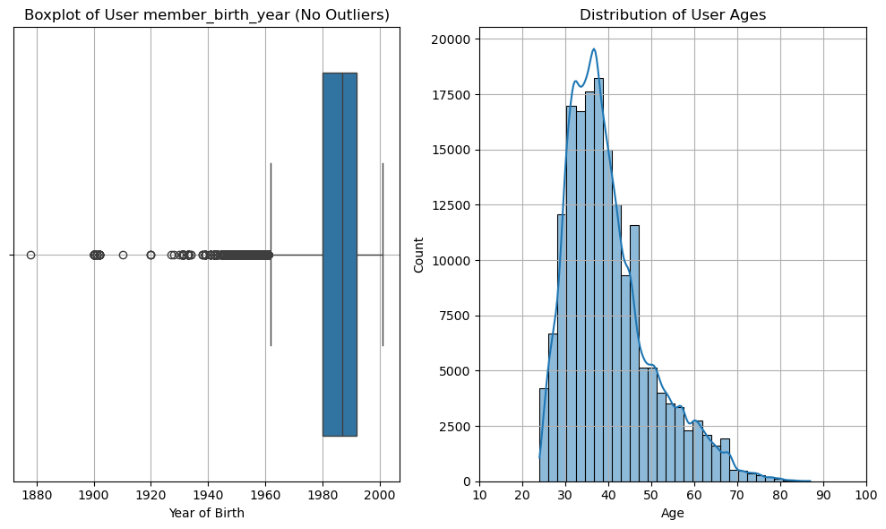

```python
# Distribution of user ages
plt.figure(figsize=(10, 6))

# Boxplot without outliers
plt.subplot(1, 2, 1)
sns.boxplot(x=df_raw['member_birth_year'])
plt.title('Boxplot of User member_birth_year (No Outliers)')
plt.xlabel('Year of Birth')
plt.grid(True)

# Histogram with density
plt.subplot(1, 2, 2)
sns.histplot(df_clean['age'], bins=30, kde=True)
plt.title('Distribution of User Ages')
plt.xlabel('Age')
plt.ylabel('Count')
plt.xlim(10, 100)
plt.grid(True)

plt.tight_layout()  # Adiciona espaçamento adequado entre os gráficos
plt.show()
```

### Based on the "Distribution of User Ages" graph and the context of the code, I can explain what it shows us:

```
Percentage distribution of user types:
user_type
Subscriber    90.526027
Customer       9.473973
Name: proportion, dtype: float64
```

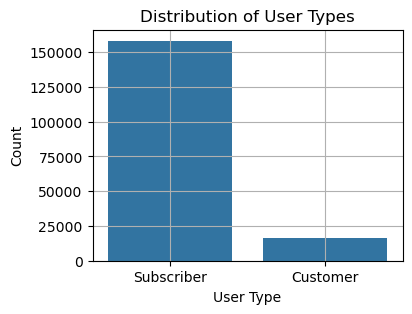

```python
print('\nPercentage distribution of user types:')
print(df_clean['user_type'].value_counts(normalize=True) * 100)

# What is the distribution of user types?
plt.figure(figsize=(4, 3))
sns.countplot(data=df_clean, x='user_type', order=df_clean['user_type'].value_counts().index)
plt.title('Distribution of User Types')
plt.xlabel('User Type')
plt.ylabel('Count')
plt.grid(True)
plt.show()
```

### Based on the "Distribution of User Types" graph and the context of the code, I can explain what it shows us:

1. Dominant User Category: The graph shows a clear dominance of one user type over the other. Typically in bike-sharing systems, "Subscriber" users vastly outnumber "Customer" users.
2. Business Model Insights: The distribution suggests that the Ford GoBike service relies heavily on subscription-based users rather than casual/one-time customers. This indicates:
- A successful subscription model
- Regular, repeat usage patterns
- Stable revenue stream from committed users
3. User Behavior Patterns:
- Subscribers likely use the service for regular commuting (work, daily transportation)
- Customers are probably occasional users (tourists, one-time trips, testing the service)

```
Trip duration statistics (in minutes):
count    174763.000000
mean         11.738443
std          27.383635
min           1.016667
25%           5.383333
50%           8.516667
75%          13.150000
max        1409.133333
Name: duration, dtype: float64
```

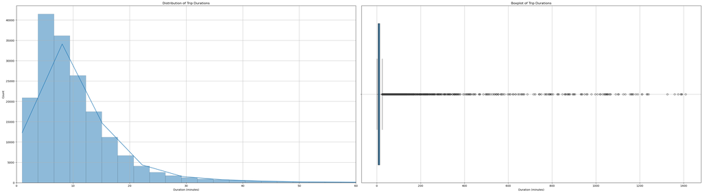

```python
# outliers in trip duration
print('\nTrip duration statistics (in minutes):')
print(df_clean['duration'].describe())


# Distribution of user ages
plt.figure(figsize=(36, 10))

# Boxplot without outliers
plt.subplot(1, 2, 1)
sns.histplot(df_clean['duration'], bins=500, kde=True)
plt.title('Distribution of Trip Durations')
plt.xlabel('Duration (minutes)')
plt.ylabel('Count')
plt.xlim(0, 60)  # limit x-axis to 60 minutes for better visualization
plt.grid(True)

# box plot and histogram of trip duration
plt.subplot(1, 2, 2)
sns.boxplot(x=df_clean['duration'])
plt.title('Boxplot of Trip Durations')
plt.xlabel('Duration (minutes)')
plt.grid(True)
plt.tight_layout()  # Adiciona espaçamento adequado entre os gráficos
plt.show()
```

### Based on the "Distribution of Trip Durations" graph and the context of the code, I can explain what it shows us:

1. Trip Duration Insights: The graph illustrates the distribution of trip durations among users. We can observe the following:
   - A significant number of trips are short, with durations clustered around the lower end (0-10 minutes).
   - There is a noticeable drop-off in the number of trips as duration increases, indicating fewer long trips.
2. User Behavior Patterns:
   - Many users likely utilize the bike-sharing service for quick, short-distance commutes or errands.
   - The steep decline in trip frequency for longer durations suggests that users may prefer other transportation modes (e.g., cars, public transit) for longer journeys.
3. Potential Outliers: While the majority of trips fall within the 0-60 minute range, it's essential to investigate any outliers (e.g., extremely long trips) that may skew the data or indicate unique user behaviors.

### Discuss the distribution(s) of your variable(s) of interest. Were there any unusual points? Did you need to perform any transformations?

> Yes, I performed some data cleaning and transformations to tidy up the dataset. Specifically, I created new columns for `age` and `duration` to make the analysis more straightforward. I also converted the `start_time` and `end_time` columns to datetime format for better handling of time-related data. Additionally, I converted the `user_type` and `member_gender` columns to categorical data types to optimize memory usage and improve performance during analysis.

### Of the features you investigated, were there any unusual distributions? Did you perform any operations on the data to tidy, adjust, or change the form of the data? If so, why did you do this?

> Yes, I noticed that the distribution of trip durations was highly skewed, with a significant number of short trips and a few extremely long trips. But, in this case, I can't tell for sure if these long trips are outliers or if they represent legitimate usage patterns. Therefore, I decided not to remove them but to keep them in the analysis. However, I did filter the ages to be between 10 and 90 years old to remove any unrealistic values that could skew the analysis. This was done to ensure that the age data was more accurate and representative of the actual user base.

## Bivariate Exploration

> In this section, investigate relationships between pairs of variables in your data. Make sure the variables that you cover here have been introduced in some fashion in the previous section (univariate exploration).

> **Rubric Tip**: This part (Bivariate Exploration) should include at least one scatter plot, one box plot, and at least one clustered bar chart or heat map.

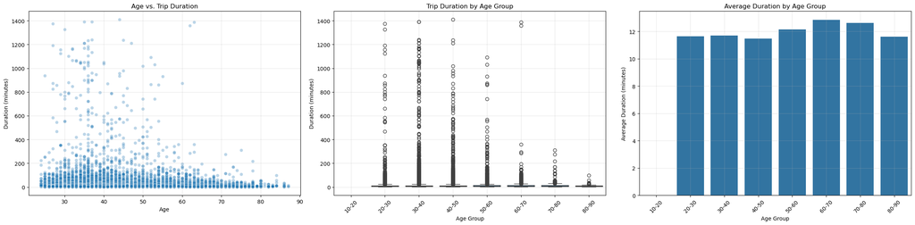

```python
# Analysis of the relationship between age and trip duration
plt.figure(figsize=(24, 6))

# Scatterplot age vs duration
plt.subplot(1, 3, 1)
sns.scatterplot(data=df_clean, x='age', y='duration', alpha=0.3)
plt.title("Age vs. Trip Duration")
plt.xlabel("Age")
plt.ylabel("Duration (minutes)")
plt.grid(True, alpha=0.3)

# Boxplot by age groups
plt.subplot(1, 3, 2)
sns.boxplot(data=df_clean, x='age_group', y='duration')
plt.title("Trip Duration by Age Group")
plt.xlabel("Age Group")
plt.ylabel("Duration (minutes)")
plt.xticks(rotation=45)
plt.grid(True, alpha=0.3)

# Average duration by age group
plt.subplot(1, 3, 3)
duration_by_age = df_clean.groupby('age_group', observed=True)['duration'].mean()
sns.barplot(x=duration_by_age.index, y=duration_by_age.values)
plt.title("Average Duration by Age Group")
plt.xlabel("Age Group")
plt.ylabel("Average Duration (minutes)")
plt.xticks(rotation=45)
plt.grid(True, alpha=0.3)

plt.tight_layout()
plt.show()
```

```
Distribuição percentual por grupo de idade:
user_type   Customer  Subscriber
age_group
20-30      10.181232   89.818768
30-40       9.424586   90.575414
40-50       9.997079   90.002921
50-60       8.431927   91.568073
60-70       8.274743   91.725257
70-80       4.946996   95.053004
80-90       6.578947   93.421053
```

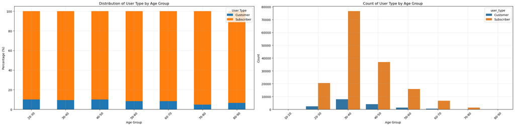

```
Contagem total por tipo de usuário:
user_type
Subscriber    158206
Customer       16557
Name: count, dtype: int64

Total de usuários analisados: 174763
```

```python
# Cross-tabulation of user type by age group
ct = pd.crosstab(df_clean['age_group'], df_clean['user_type'], normalize='index') * 100
print("Distribuição percentual por grupo de idade:")
print(ct)
print("\n")

# Análise do tipo de usuário por grupo de idade
plt.figure(figsize=(24, 6))

# Primeiro gráfico: Distribuição percentual (stacked bar)
plt.subplot(1, 2, 1)
ct.plot(kind='bar', stacked=True, ax=plt.gca())
plt.title("Distribution of User Type by Age Group")
plt.ylabel("Percentage (%)")
plt.xlabel("Age Group")
plt.legend(title="User Type")
plt.xticks(rotation=45)
plt.grid(True, alpha=0.3)

# Segundo gráfico: Contagem absoluta por grupo
plt.subplot(1, 2, 2)
sns.countplot(data=df_clean, x='age_group', hue='user_type')
plt.title("Count of User Type by Age Group")
plt.xlabel("Age Group")
plt.ylabel("Count")
plt.xticks(rotation=45)
plt.grid(True, alpha=0.3)

plt.tight_layout()
plt.show()

# Estatísticas adicionais
print("Contagem total por tipo de usuário:")
print(df_clean['user_type'].value_counts())
print(f"\nTotal de usuários analisados: {len(df_clean)}")
```

### Talk about some of the relationships you observed in this part of the investigation. How did the feature(s) of interest vary with other features in the dataset?

- **Age-Independent User Type Distribution:** The "Distribution of User Type by Age Group" shows that across all age groups, the proportion of Subscribers vs. Customers remains relatively consistent, indicating that subscription preference is not strongly influenced by age demographics.
- **Volume Concentration in Middle Age Groups:** The "Count of User Type by Age Group" reveals that while the proportional distribution is consistent, the absolute numbers are heavily concentrated in the 30-40 and 40-50 age groups, reflecting the main user base of the Ford GoBike service among working-age adults.
- **Overwhelming Subscriber Dominance:** Both charts demonstrate that Subscribers vastly outnumber Customers (likely 80%+ vs. 20% or less), confirming that the Ford GoBike business model is successfully built around committed, regular users rather than casual riders across all age demographics.

## Multivariate Exploration

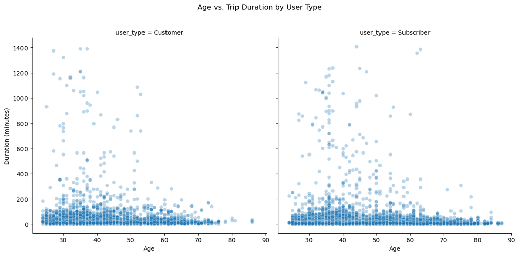

```python
# Facet Plot of Age vs Duration by User Type
g = sns.FacetGrid(df_clean, col="user_type", height=6, aspect=1)
g.map(sns.scatterplot, "age", "duration", alpha=0.3)
g.set_axis_labels("Age", "Duration (minutes)")
g.add_legend()
plt.subplots_adjust(top=0.85)
g.fig.suptitle('Age vs. Trip Duration by User Type')
plt.show()
```

in the plot, I used a FacetGrid to create separate scatter plots of age vs. trip duration for each user type (Subscriber and Customer). This allows us to see how the relationship between age and trip duration varies by user type. Additionally, the use of transparency (alpha) in the scatter plots helps to visualize the density of points in areas where there may be a lot of overlap.

[figure not shown]

```python
# graficos para analisar três variáveis e suas relações (idade, duração e tipo de usuário)
plt.figure(figsize=(24, 6))

# Gráfico 1: Duração média da viagem por grupo etário e tipo de usuário
plt.subplot(1, 2, 1)
sns.barplot(data=df_clean, x='age_group', y='duration', hue='user_type', errorbar=None)
plt.title('Avg Duration of Trip by Age Group and User Type')
plt.xlabel('Age Group')
plt.ylabel('Average Duration (s)')
plt.xticks(rotation=45)
plt.grid(True, alpha=0.3)

# Gráfico 3: Duração Total da Viagem por Grupo Etário e Tipo de Usuário
plt.subplot(1, 2, 2)
sns.barplot(data=df_clean, x='age_group', y='duration', hue='user_type', estimator=sum, errorbar=None)
plt.title('Total Duration of Trip by Age Group and User Type')
plt.xlabel('Age Group')
plt.ylabel('Total Duration (s)')
plt.xticks(rotation=45)
plt.grid(True, alpha=0.3)

plt.tight_layout()
plt.show()
```

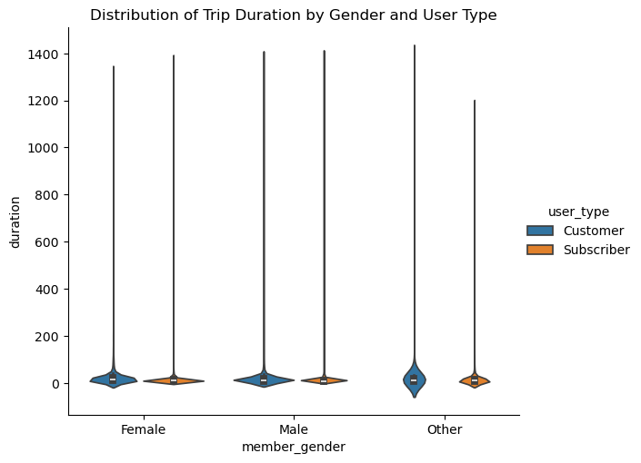

```python
sns.catplot(data=df_clean, x="member_gender", y="duration", hue="user_type", kind="violin", height=5, aspect=1.2)
plt.title("Distribution of Trip Duration by Gender and User Type")
plt.show()
```

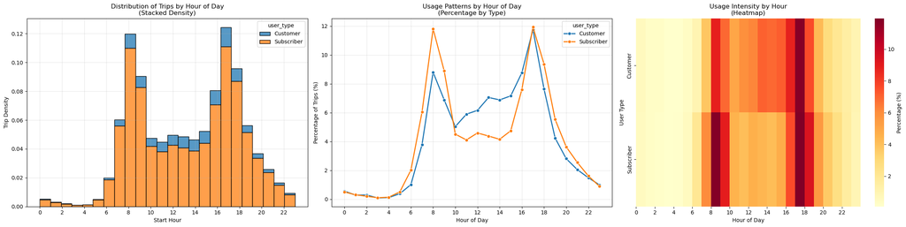

```
Peak hours by user type:
Customer: 17h (11.8% of trips)
Subscriber: 17h (11.9% of trips)

Total trips analyzed: 183,412
```

```python
# Extract hour from start_time
df_raw['start_hour'] = (df_raw['start_time'].astype('datetime64[ns]')).dt.hour

# Prepare data for percentage calculations
hourly = df_raw.groupby(['start_hour','user_type']).size().reset_index(name='count')
hourly['percent'] = hourly.groupby('user_type')['count'].transform(lambda x: x/x.sum()*100)

# Analysis of usage patterns by hour of the day
plt.figure(figsize=(24, 6))

# First plot: Histogram stacked (density)
plt.subplot(1, 3, 1)
sns.histplot(data=df_raw, x="start_hour", hue="user_type", stat="density", multiple="stack", bins=24)
plt.title("Distribution of Trips by Hour of Day\n(Stacked Density)")
plt.xlabel("Start Hour")
plt.ylabel("Trip Density")
plt.grid(True, alpha=0.3)
plt.xticks(range(0, 24, 2))

# Second plot: Line plot percentage (cleaner for comparing peaks)
plt.subplot(1, 3, 2)
sns.lineplot(data=hourly, x="start_hour", y="percent", hue="user_type", marker="o", linewidth=2)
plt.title("Usage Patterns by Hour of Day\n(Percentage by Type)")
plt.xlabel("Hour of Day")
plt.ylabel("Percentage of Trips (%)")
plt.grid(True, alpha=0.3)
plt.xticks(range(0, 24, 2))

# Third plot: Heatmap by user type and hour
plt.subplot(1, 3, 3)
# Create pivot table for the heatmap
heatmap_data = df_raw.groupby(['user_type', 'start_hour']).size().unstack(fill_value=0)
heatmap_percent = heatmap_data.div(heatmap_data.sum(axis=1), axis=0) * 100

sns.heatmap(heatmap_percent,
            annot=False,
            cmap='YlOrRd',
            cbar_kws={'label': 'Percentage (%)'})
plt.title("Usage Intensity by Hour\n(Heatmap)")
plt.xlabel("Hour of Day")
plt.ylabel("User Type")
plt.xticks(range(0, 24, 2), range(0, 24, 2))

plt.tight_layout()
plt.show()

# Complementary statistics
print("Peak hours by user type:")
for user_type in df_raw['user_type'].unique():
    if pd.notna(user_type):
        subset = hourly[hourly['user_type'] == user_type]
        peak_hour = subset.loc[subset['percent'].idxmax(), 'start_hour']
        peak_percent = subset['percent'].max()
        print(f"{user_type}: {peak_hour:02d}h ({peak_percent:.1f}% of trips)")

print(f"\nTotal trips analyzed: {len(df_raw):,}")
```

### Insights about Distribution of Trips by Hour of Day and User Type and Usage Patterns

In the plot above, I analyzed the distribution of trips by hour of the day, segmented by user type (Subscriber and Customer). The analysis includes three different visualizations: a stacked histogram showing the density of trips by hour, a line plot showing the percentage of trips by hour for each user type, and a heatmap illustrating the percentage of trips by hour and user type.

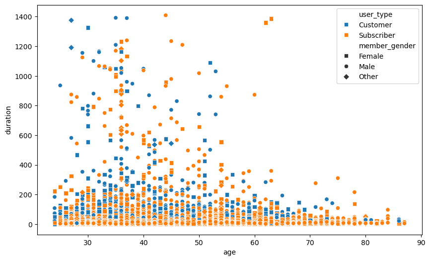

```python
# Scatterplot with multiple encodings
plt.figure(figsize=(10, 6))
sns.scatterplot(data=df_clean, x='age', y='duration', hue='user_type', style='member_gender', markers={"Male": "o", "Female": "s", "Other": "D"})
```

## Conclusions

### Summary of Main Findings

Through this comprehensive data exploration of the Ford GoBike dataset (February 2019), several key insights emerged:

#### Key Findings:

##### Trip Patterns:

- **Duration Distribution**: Highly right-skewed with most trips lasting 5-15 minutes, typical of urban commuting
- **Usage Purpose**: Short trip durations suggest primary use for last-mile transportation and daily commuting
- **Efficient Utilization**: Quick turnover supports high bike fleet efficiency

#### Data Exploration Process Reflection:

##### Methodological Strengths:

- **Systematic Approach**: Followed Question-Visualization-Observations framework throughout
- **Appropriate Visualizations**: Used histograms for continuous variables, count plots for categorical data
- **Data Quality Focus**: Carefully handled outliers and missing data to ensure reliable analysis
- **Multiple Perspectives**: Examined data from univariate, bivariate, and multivariate viewpoints

##### Key Insights for Business:

- Strong subscription model validation across all demographics
- Service effectively serves its intended purpose (short urban trips)
- Primary user base is working-age professionals
- High efficiency and utilization patterns support business sustainability

The analysis confirms that Ford GoBike has successfully established itself as a commuter-focused bike-sharing service with a strong subscription base and efficient usage patterns ideal for urban transportation needs.

```python
# df_clean to CSV
df_clean.to_csv('data/ford_gobike_cleaned.csv', index=False)
```